# Sounds of San Anto

Erick Lima

2026-03-31

# Introduction

This notebook presents a surface-level exploratory analysis of the dataset. The goal is to identify patterns and potential connections between concert activity, venue geography, genre trends, and demographic factors such as race and income — laying the groundwork for deeper analysis.

## Load Data

The following loads data from the source Excel file and saves it to the dataframe *my_data*.

```r
my_data <- read_excel("san_anto_1.xlsx")
head(my_data)
```

```
## # A tibble: 6 × 14
##   Index Month   Day   Year  Venue Event_Artists Address   Zip Longitude Latitude
##   <dbl> <chr>   <chr> <chr> <chr> <chr>         <chr>   <dbl>     <dbl>    <dbl>
## 1  7824 Septem… 30    1988  Jack… Chris & Judy  2950 T… 78247     -98.4     29.6
## 2  7978 Septem… 7     1988  Jack… Geronimo Tre… 2950 T… 78247     -98.4     29.6
## 3  7978 Septem… 7     1988  Jack… Geronimo Tre… 2950 T… 78247     -98.4     29.6
## 4  8014 Septem… 10    1988  Jack… Primitve Mod… 2950 T… 78247     -98.4     29.6
## 5  8141 Septem… 23    1988  Jack… Stockton and… 2950 T… 78247     -98.4     29.6
## 6  8165 Septem… 24    1988  Jack… Bob Barranski 2950 T… 78247     -98.4     29.6
## # ℹ 4 more variables: Artist <chr>, Event <chr>, City <chr>, State <chr>
```

## Show Concerts per Year

We first diplay the number of concerts occuring per year in San Antonio.

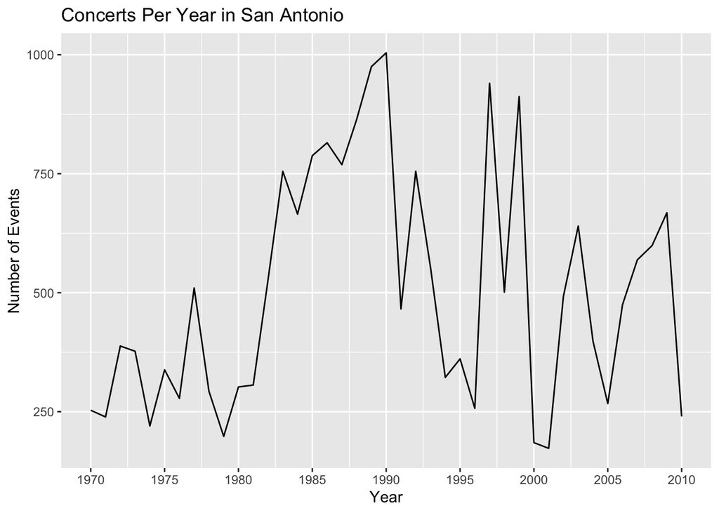

```r
## Filtering
events_per_year <- my_data %>%
  count(Year) %>%
  arrange(Year)
## Plotting
ggplot(events_per_year, aes(x = as.numeric(Year), y = n)) +
  geom_line() +
  labs(title = "Concerts Per Year in San Antonio",
       x = "Year", y = "Number of Events") +
  scale_x_continuous(breaks = seq(1950, 2020, by = 5))
```

We are able to see that from this data set that the number of concerts grew tremendously during the 1980s and that between the 1990 and 1995 the number of concerts decreased and not bouncing back until 1997. More analysis would have to be done to determine if this is due to an economic, political etc. or if this is just due to an incomplete data set.

## Busiest Months for Concerts

Here we find the number of concerts that occur per month through out all the years of the data set.

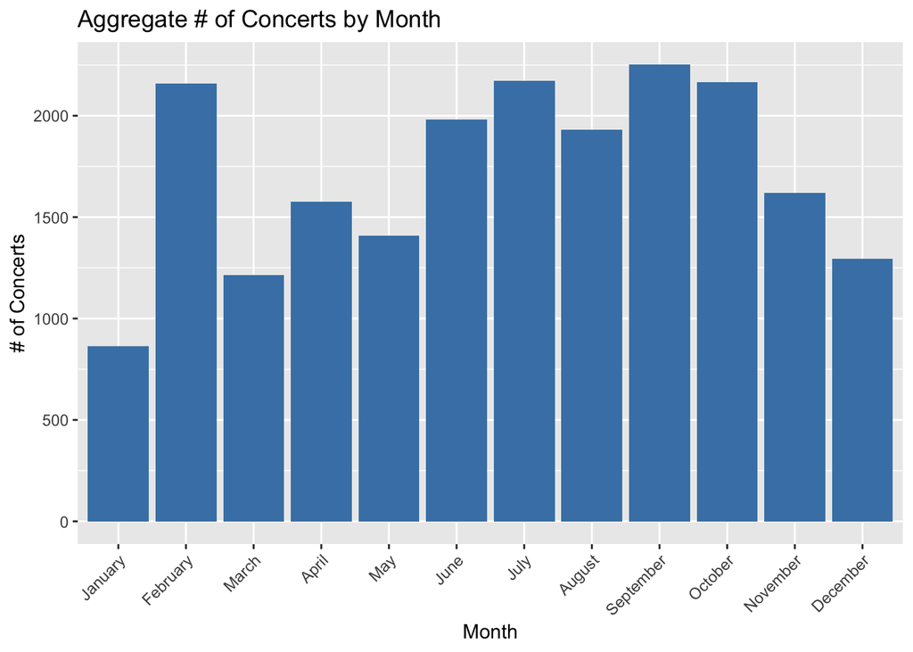

```r
# Filtering
events_per_month_year <- my_data %>%
  count(Year, Month) %>%
  mutate(Month = factor(Month, levels = month.name))
# Plotting
#ggplot(events_per_month_year, aes(x = as.numeric(Year), y = Month, fill = n)) +
#  geom_tile() +
#  scale_fill_viridis_c() +
#  labs(title = "Concerts by Month and Year",
#       x = "Year", y = "Month", fill = "Events")

ggplot(events_per_month_year, aes(x = Month, y = n)) +
  geom_col(fill = "steelblue") +
  labs(
    x = "Month",
    y = "# of Concerts",
    title = "Aggregate # of Concerts by Month"
  ) +
  theme(
    axis.text.x = element_text(angle = 45, hjust = 1)
  )
```